# Week 7: CFA Specification

EDEP 625 Structural Equation Modeling

Susanne DeVore, PhD

2026-10-14

# Agenda

- CFA Intro
- CFA Path Diagrams & Sysems of Equations
- CFA Model Implied Covariance
- Implications of CFA
- Specifying CFA in Lavaan
- Rlab

# Overview

Fundamentally the same:

- Theory remains the motivation for all specification decisions
- Specify a theoretically motivated model
- Estimate parameters so that model-implied covariance matrix is as close to observed as possible

Key difference:

- Relationship between measured variables (indicators) and latent variables

# Review

Definition of latent variables

# Reframe

**MVPA RQ:** What is the effect of parent education on reading score through books in the home?

**Latent Variable RQ:** To what extent do parent education, books in the home, and technology in the home reflect a single latent socioeconomic status variable?

## System of equations

**MVPA**

$$\begin{aligned}
\text{Books} &= a_0 + a_1\,(\text{ParentEd}) + \zeta_B \\
\text{Reading} &= b_0 + b_1\,(\text{Books}) + \zeta_R
\end{aligned}$$

**Latent Variable**

$$\begin{aligned}
\text{ParentEd} &= \tau_1 + \lambda_1\,\text{SES} + \varepsilon_1 \\
\text{BooksHome} &= \tau_2 + \lambda_2\,\text{SES} + \varepsilon_2 \\
\text{TechHome} &= \tau_3 + \lambda_3\,\text{SES} + \varepsilon_3
\end{aligned}$$

Where:

- τ = intercept
- λ = path coefficient
- ε = residual

# Systems of equations to path diagrams

## Path Diagrams Review

What do the following represent?

- squares/rectangles
- Single-headed straight arrow
- curved double headed arrow
- Circles/ovals: latent variables

## Path diagram MVPA

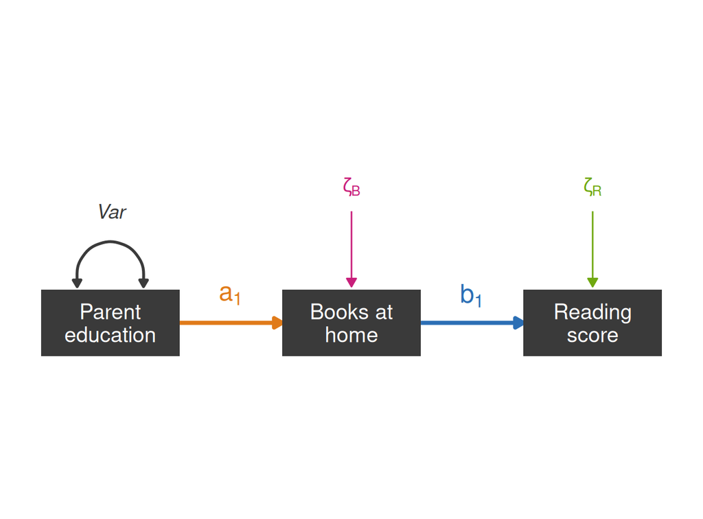

## Path diagram Latent Variable

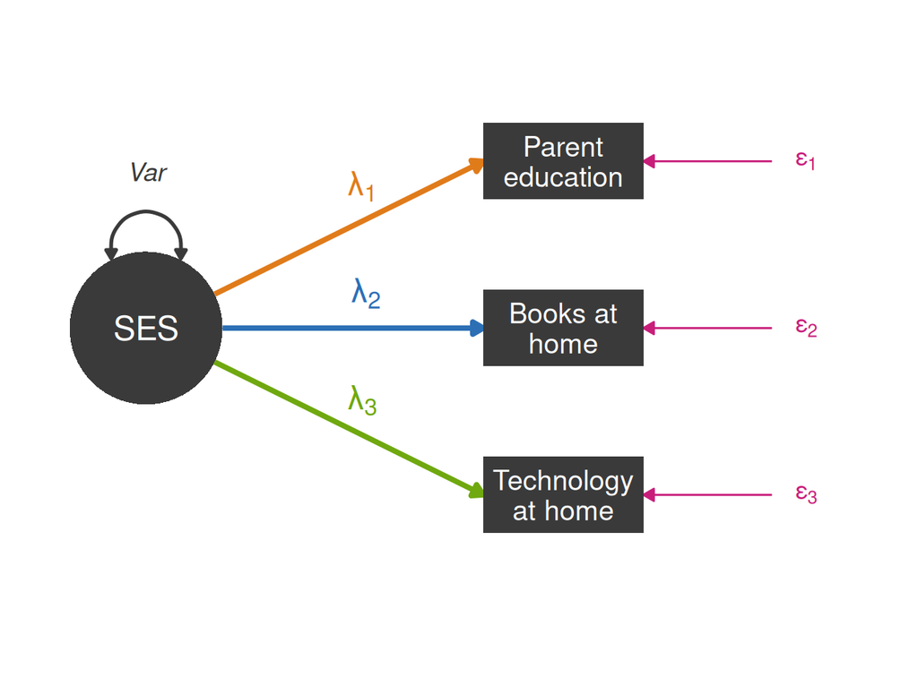

# Model-implied covariance matrix

- Use path tracing rules & the path diagram

## Review path tracing rules

Take a few minutes to review the path tracing rules from [Lecture 3](https://srdevore.github.io/edep_625_sem/lectures/w03_mvpa_specification.html#/title-slide).

Then you’ll decide if some paths are allowed or not allowed.

## Allowed or not allowed?

For each example, the **magenta** path is the route to evaluate. Is it an allowed route?

## Allowed or not allowed?

**Route:** Parent education → Books at home → Reading score

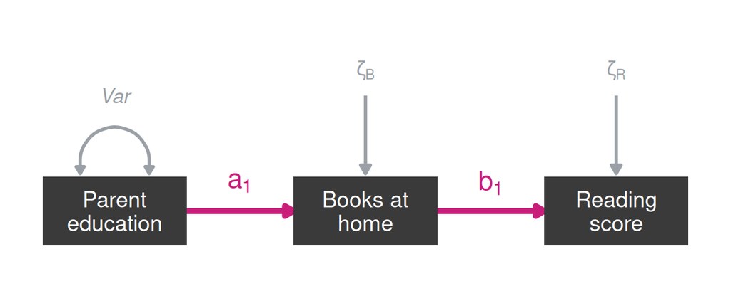

## Allowed or not allowed?

**Route:** Parent education ← SES → Books at home

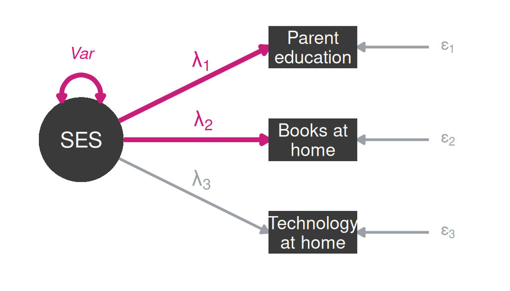

## Allowed or not allowed?

**Route:** Parent education ← SES ↺ SES ↺ SES → Technology at home

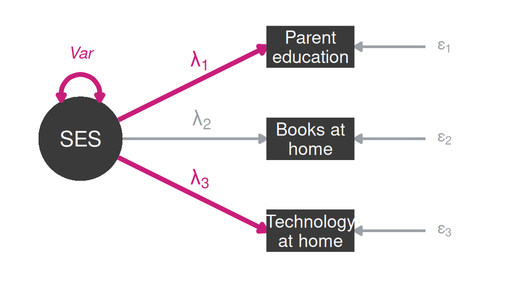

## Allowed or not allowed?

**Route:** Parent education → Books at home ← ζ<sub>B</sub>

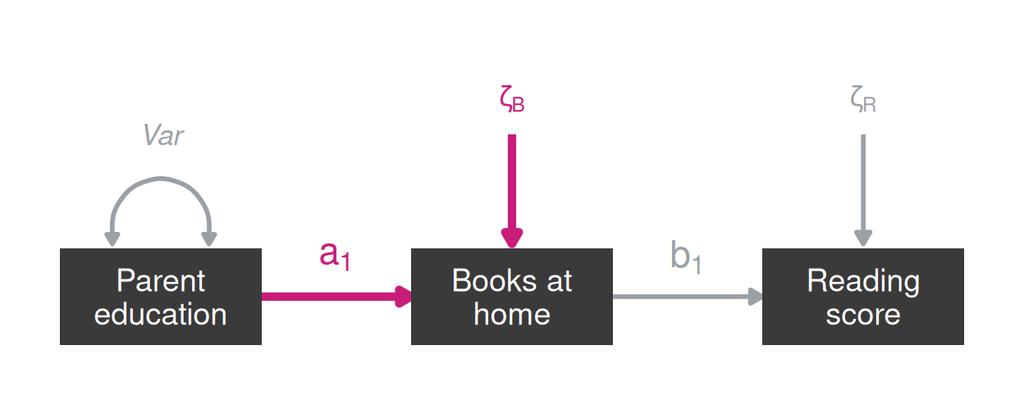

## Allowed or not allowed?

**Route:** Parent education ← SES → Books at home ← SES → Technology at home

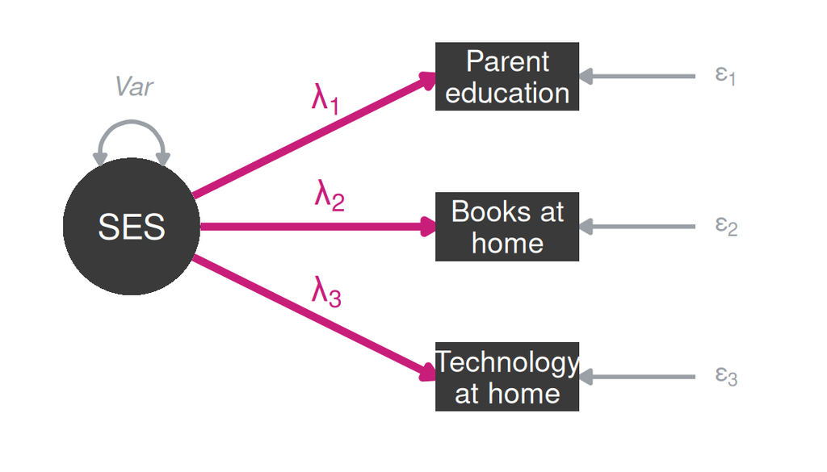

## Allowed or not allowed?

**Route:** Books at home ← Parent education ↺ Parent education → Books at home

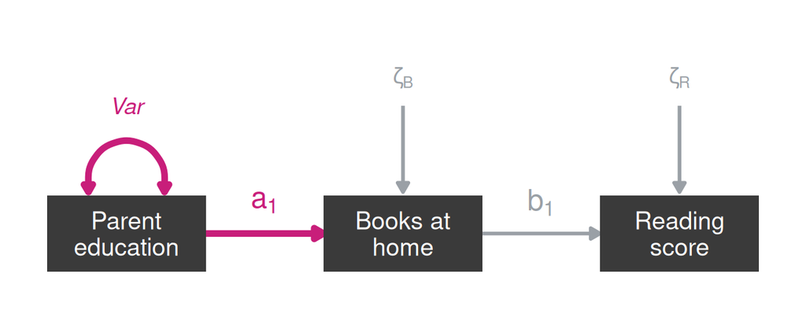

## Review: Getting Model-implied cov

First identify the paths using tracing rules:

1. A route may go backward against an arrowhead, then forward with an arrowhead — but never forward-then-backward.
2. Never pass through the same variable twice in one route (no loops).
3. A route may pass through at most one curved double-headed (covariance) arrow, and only at the route’s turning point.

## Review: Getting model-implied covariance

Then get the covariance using the paths

1. Find every valid route between the two variables (following the rules above).
2. For each route, multiply together all the path coefficients (and the one correlation/covariance term, if a curved arrow is involved).
3. Multiply the whole product by the variance of the route’s ultimate common source variable.
4. Sum the contributions across all valid routes — that sum equals the total covariance between the two variables.

## Latent Variable Model-implied Covariance

The path diagram is simply a representation of the system of equations

$$\begin{aligned}
\text{ParentEd} &= \tau_1 + \lambda_1\,\text{SES} + \varepsilon_1 \\
\text{BooksHome} &= \tau_2 + \lambda_2\,\text{SES} + \varepsilon_2 \\
\text{TechHome} &= \tau_3 + \lambda_3\,\text{SES} + \varepsilon_3
\end{aligned}$$

*PE = Parent ed · BH = Books at home · TH = Technology at home · S = SES*

## Trace 1 — Var(Parent ed)

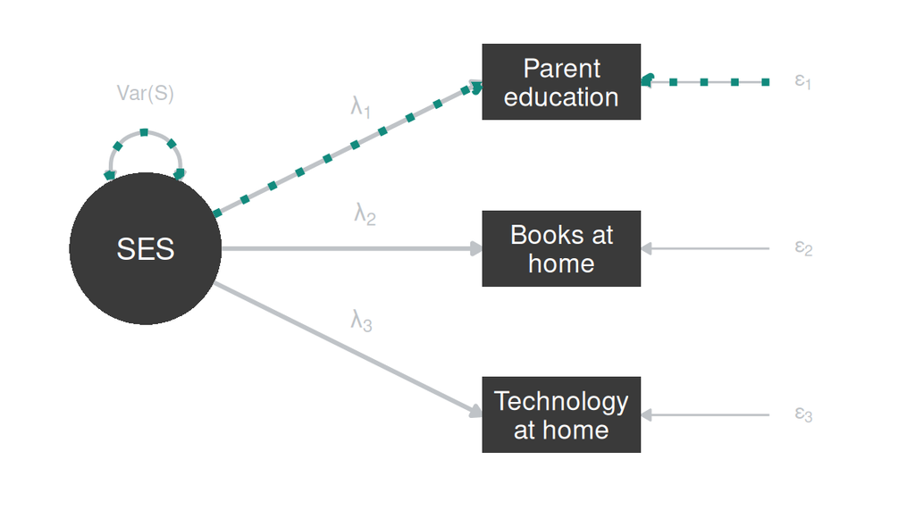

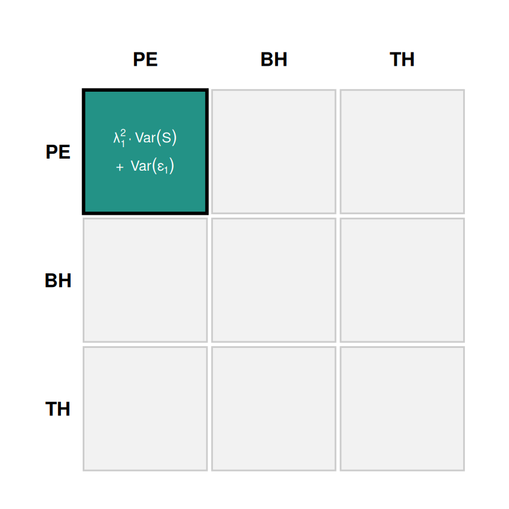

**Var(PE):** trace PE to itself. Up-and-back through the common cause SES → λ₁²·Var(S); plus its own residual → Var(ε₁). Sum the routes.

## Trace 2 — Cov(Parent ed, Books)

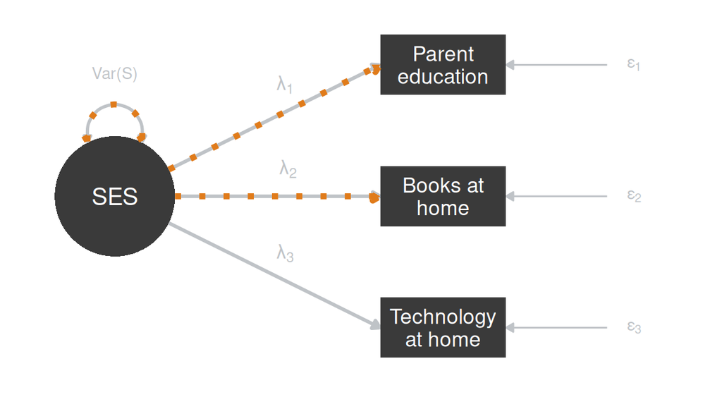

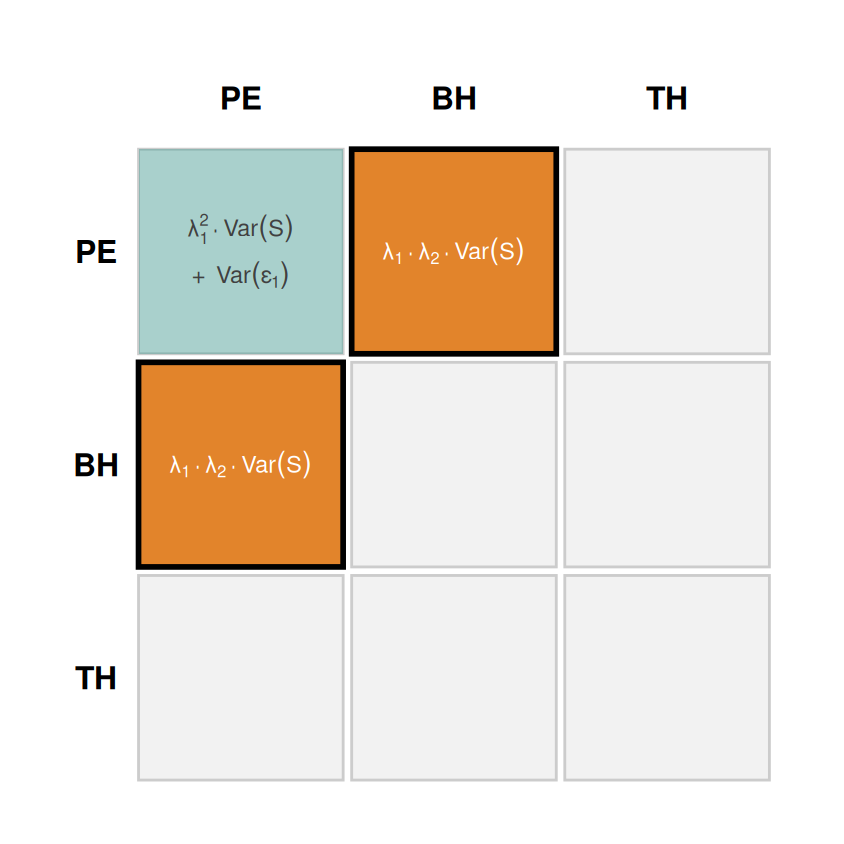

**Cov(PE, BH):** one route PE ← SES → BH (backward, forward). Multiply the loadings λ₁·λ₂, then × the variance at the top, Var(S). The indicators share only SES.

## Trace 3 — Var(Books)

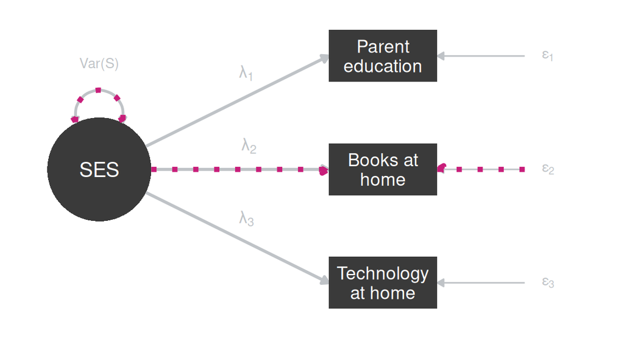

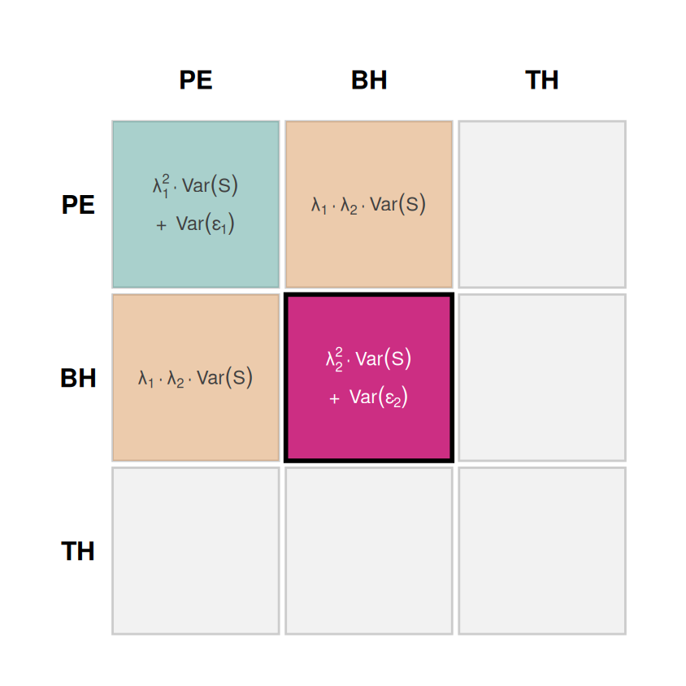

**Var(BH):** up-and-back through SES → λ₂²·Var(S); plus its own residual → Var(ε₂). Sum.

## Trace 4 — Cov(Parent ed, Technology)

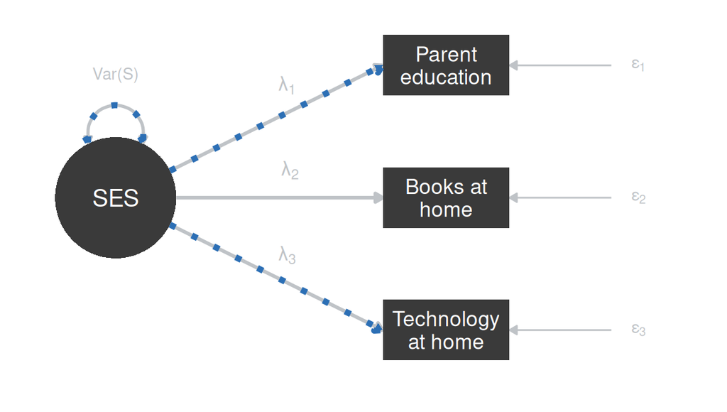

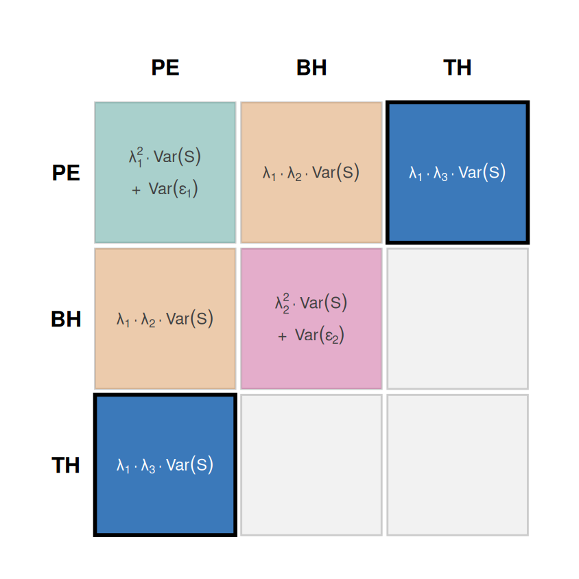

**Cov(PE, TH):** one route PE ← SES → TH. Multiply λ₁·λ₃, then × Var(S).

## Trace 5 — Cov(Books, Technology)

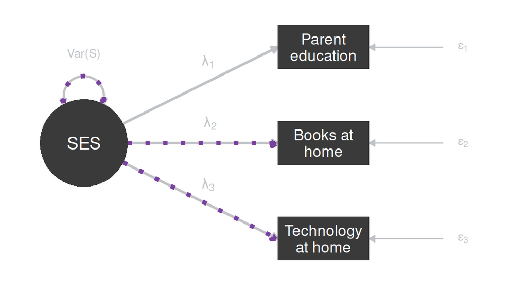

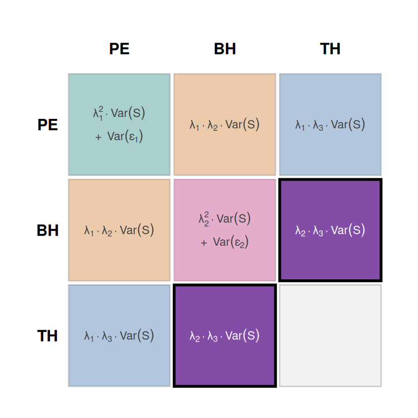

**Cov(BH, TH):** one route BH ← SES → TH. Multiply λ₂·λ₃, then × Var(S).

## Trace 6 — Var(Technology)

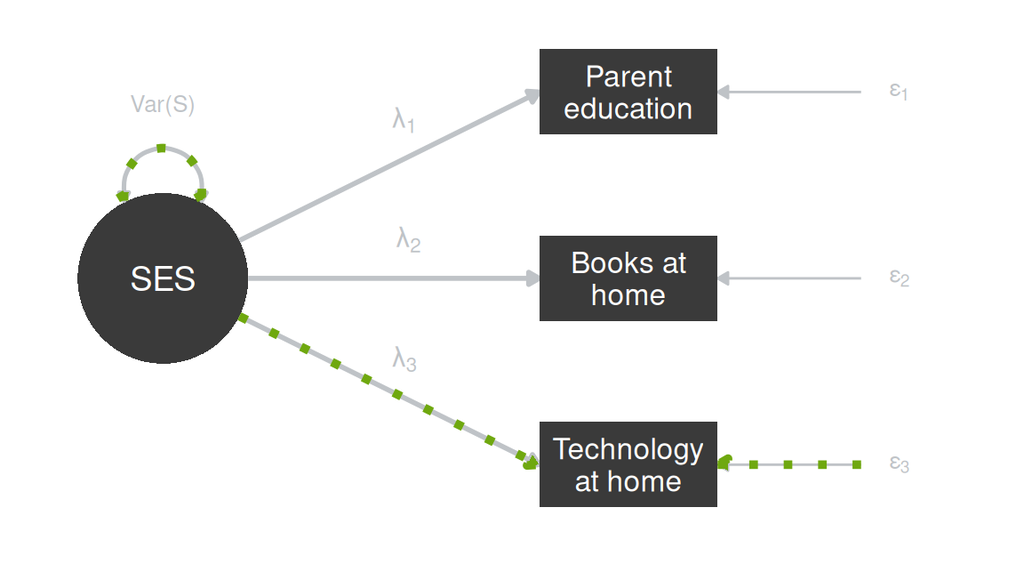

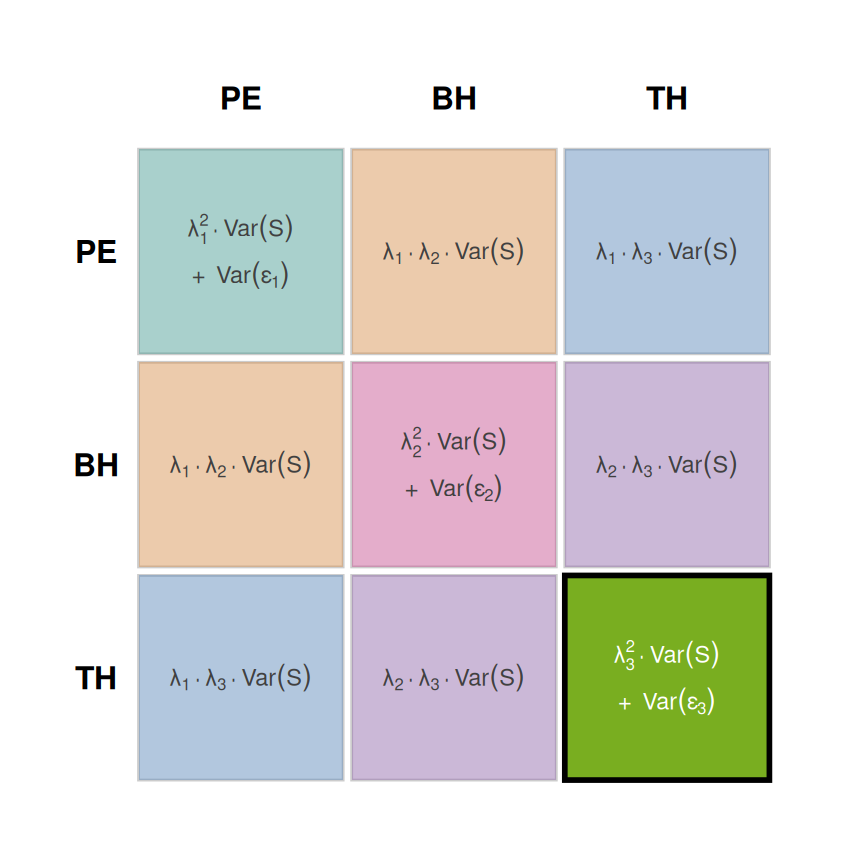

**Var(TH):** up-and-back through SES → λ₃²·Var(S); plus its own residual → Var(ε₃). Sum.

## Practice

Motivation is measured by **Effort1**, **StudyHmW**, and **MissSc**.

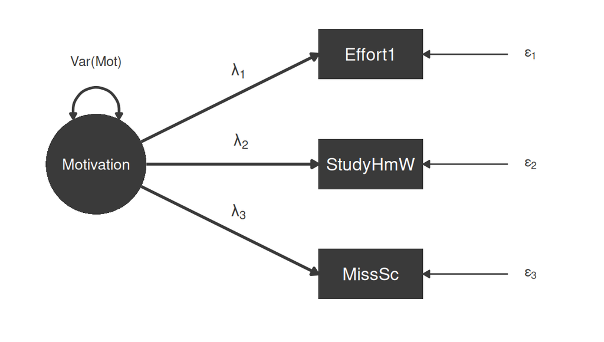

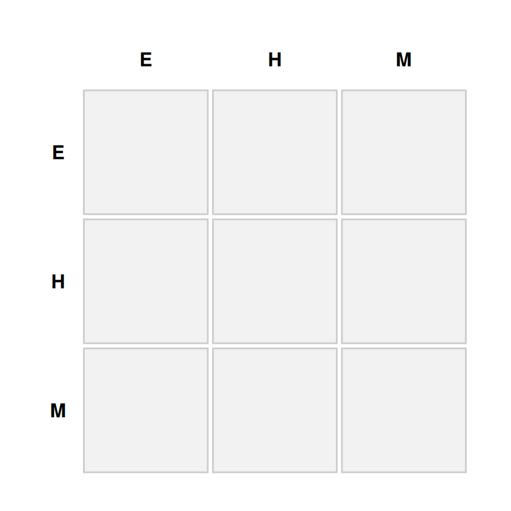

## Practice: system of equations

Write the system of equations for the Motivation model.

$$\begin{aligned}
\text{Effort1} &= \underline{\phantom{\lambda_1}} + \underline{\phantom{\lambda_1}}\,\underline{\phantom{\text{Motivation}}} + \underline{\phantom{\lambda_1}} \\
\text{StudyHmW} &= \underline{\phantom{\lambda_1}} + \underline{\phantom{\lambda_1}}\,\underline{\phantom{\text{Motivation}}} + \underline{\phantom{\lambda_1}} \\
\text{MissSc} &= \underline{\phantom{\lambda_1}} + \underline{\phantom{\lambda_1}}\,\underline{\phantom{\text{Motivation}}} + \underline{\phantom{\lambda_1}}
\end{aligned}$$

# Implications

## Residuals & Random Measurement Error

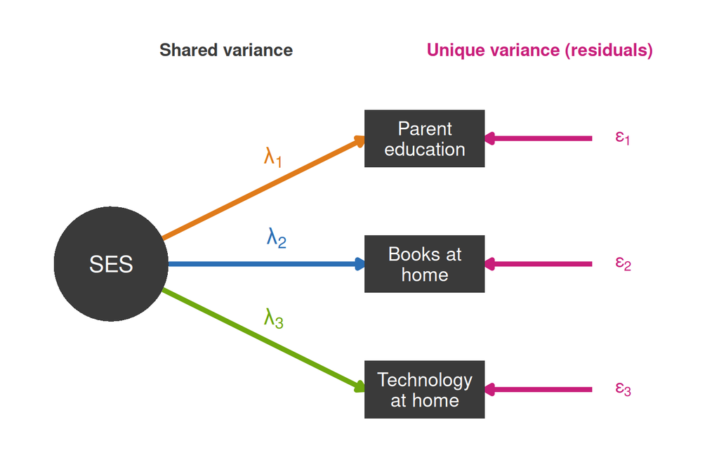

## Shared Variance & Residuals

- Shared variance: predicted or caused by the latent variable
- Residuals:
  - Random measurement error: specific to the indicator & not shared
  - True variance caused by other things

✅ Pros: Random measurement error is isolated in the indicator, not in the latent variable.

🤔 Caution: Latent variables are still succeptible to error (ex: confounding factors, reporting error)

## Scale

- What is 100 SES?
- What is 50 Motivation?

## Scale

Latent variables have no natural scale, so we need to give them one.

- Option 1: set the latent variable’s variance to 1
  - each indicator is interpreted in terms of 1-SD change in the latent variable
- Option 2: set the first loading to 1
  - each indicator is interpreted in terms of the first variable

## Parameters (q) to be estimated

| Path analysis (measured) | CFA | CFA Matrix | CFA n (guide) |
| --- | --- | --- | --- |
| Path coefficients (→ between measured vars | Path Coefficients* (factor → indicator) | Λ lambda p x k | often p |
| Variance/cov of exo var | **Factor variances/cov** | Ψ psi k x k | max of k(k+1)/2; k = n latent var |
| Disturbance variances of endo var | **Residual variances** of indicators | Θ theta p x p | p + 1 for residual cov |

*Traditionally called loadings but not in the sense of EFA/PCA or eigen decomposition.

## Parameters to be estimated

q = sum of free parameters in Λ, Ψ, Θ

- Don’t count fixed paths/variances (i.e. when scaling)

## Example

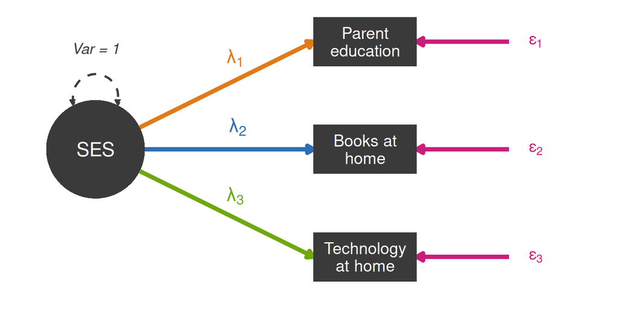

Information: 3(3+1) / 2 = 6 pieces of information

Parameters to estimate = 3 + 3 = 6

- path estimates: $\lambda_1, \lambda_2, \lambda_3$
- Residual variances: $\theta_{11}, \theta_{22}, \theta_{33}$
- Factor variance $\psi_{11}$ is fixed to 1 to scale the factor (not estimated)

## Practice

Calculate degrees of freedom for the SES model

## CFA Example 2 latent variables

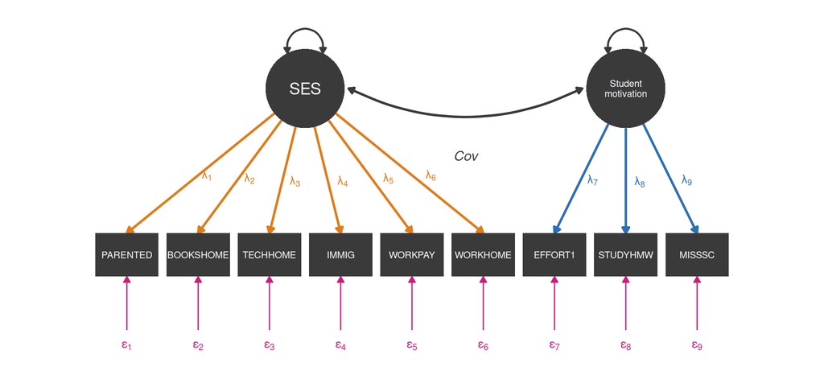

## Answers

Information: 9(9+1) / 2 = 45 pieces of information

Parameters to estimate (factor variances fixed to 1):

- path estimates: $\lambda_1, \dots, \lambda_9$ = 9
- Residual variances: $\theta_{11}, \dots, \theta_{99}$ = 9
- Factor covariance (a correlation, since variances are 1): $\psi_{21}$ = 1
- Total: 9 + 9 + 1 = 19

Degrees of freedom: 45 - 19 = 26

## CFA Example 3 latent variables

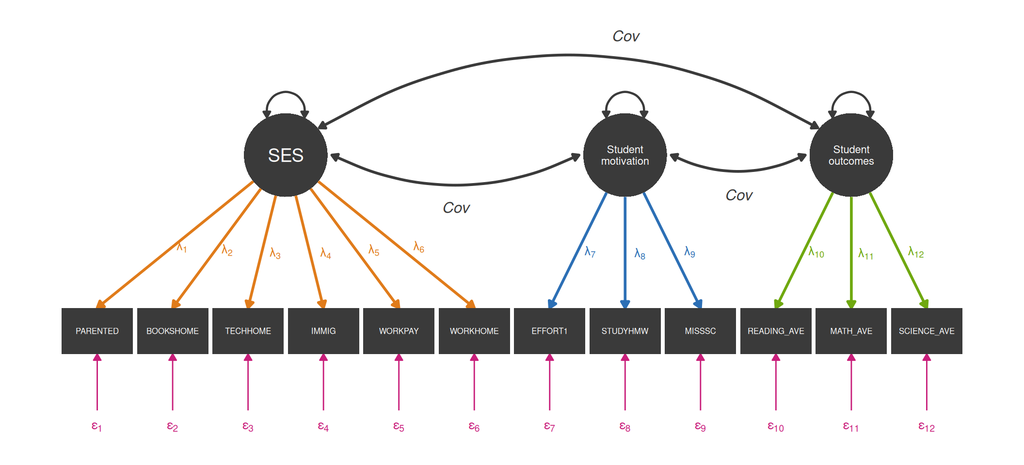

## Answers

Information: 12(12+1) / 2 = 78 pieces of information

Parameters to estimate (factor variances fixed to 1):

- path estimates: $\lambda_1, \dots, \lambda_{12}$ = 12
- Residual variances: $\theta_{11}, \dots, \theta_{12,12}$ = 12
- Factor covariances (correlations): $\psi_{21}, \psi_{31}, \psi_{32}$ = 3
- Total: 12 + 12 + 3 = 27

Degrees of freedom: 78 - 27 = 51

# Specifying CFA models in Lavaan

## Lavaan model syntax MVPA

| Symbol | Name | Meaning | Example |
| --- | --- | --- | --- |
| `~` | regression | outcome ~ predictors | `READ ~ BOOKSHOME` |
| `:=` | define parameter | new parameter computed from labelled parameters (e.g., indirect effect) | `ind := a*b` |

## Lavaan model syntax: symbols

| Symbol | Name | Meaning | Example |
| --- | --- | --- | --- |
| `=~` | measured by | latent variable → indicators (path coefficients, $\lambda$) | `SES =~ PARENTED + BOOKSHOME` |
| `~~` | covariance | variance, residual variance, or covariance | `SES ~~ MOTIV` |
| `*` | fix | fix a parameter value | `SES =~ 1*PARENTED`, `SES ~~ 1*SES` and `SES =~ NA*PARENTED` |
| `+` | plus | separates indicators or predictors | `a + b + c` |
| `#` | comment | ignored / doesn’t run | `# SES factor`, |

## Lavaan model syntax: 1st path fixed to 1

```r
cfa_model <- '
  # measurement model (first loading fixed to 1 to set the scale)
  SES   =~ 1*PARENTED + BOOKSHOME + TECHHOME
  MOTIV =~ 1*EFFORT1  + STUDYHMW  + MISSSC

  # factor variances / covariance
  SES   ~~ SES
  MOTIV ~~ MOTIV
  SES   ~~ MOTIV

  # residual variances
  PARENTED ~~ PARENTED
  BOOKSHOME ~~ BOOKSHOME
  TECHHOME ~~ TECHHOME
  EFFORT1 ~~ EFFORT1
  STUDYHMW ~~ STUDYHMW
  MISSSC ~~ MISSSC
'

fit <- lavaan(cfa_model, data = dat)
summary(fit, fit.measures = TRUE)
```

- Anything not specified is fixed to 0 (e.g., no `SES ~~ MOTIV` line means the factors are uncorrelated)

## Lavaan model syntax: factor var fixed

```r
cfa_model2 <- '
  # measurement model (all loadings free; NA* frees the first one)
  SES   =~ NA*PARENTED + BOOKSHOME + TECHHOME
  MOTIV =~ NA*EFFORT1  + STUDYHMW  + MISSSC

  # factor variances fixed to 1 to set the scale
  SES   ~~ 1*SES
  MOTIV ~~ 1*MOTIV

  # factor covariance (now a correlation)
  SES   ~~ MOTIV

  # residual variances
  PARENTED ~~ PARENTED
  BOOKSHOME ~~ BOOKSHOME
  TECHHOME ~~ TECHHOME
  EFFORT1 ~~ EFFORT1
  STUDYHMW ~~ STUDYHMW
  MISSSC ~~ MISSSC
'

fit2 <- lavaan(cfa_model2, data = dat)
summary(fit2, fit.measures = TRUE)
```

- Scale is set by fixing the factor variance (`1*`), so every loading is free
- `SES ~~ MOTIV` is now a correlation because both variances are 1
- Same model fit and df as the marker-indicator version; only the scale of the estimates differs

## Path diagram from the model syntax

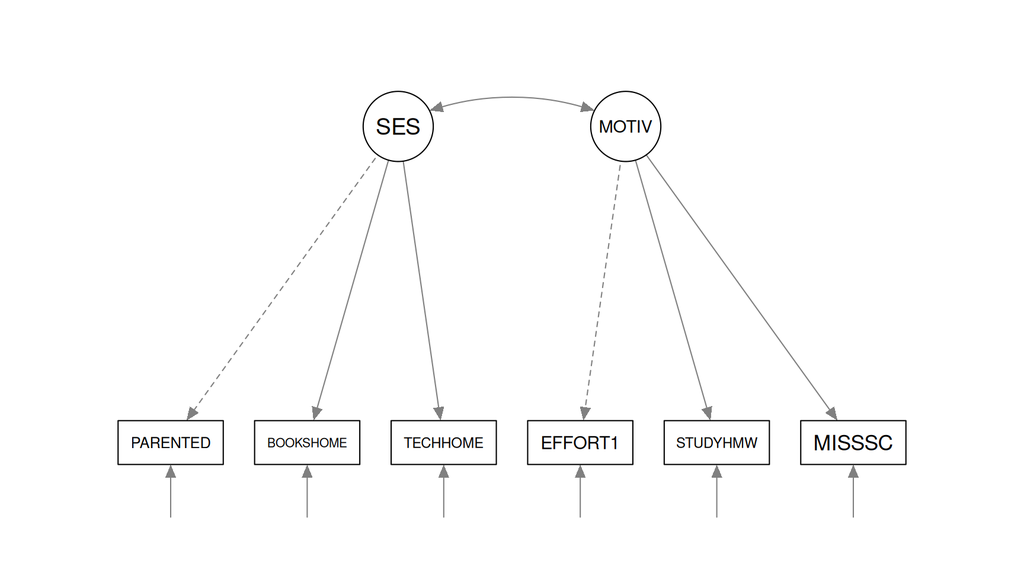

# Rlab

Go to the rlab for today.

# Up Next:

Reading on CFA Models